# FigureYa89ggplotCircos

**Author(s)**: Yuhui Li  
**Reviewer(s)**: Ying Ge, Taojun Ye  
**Date**: 2025-11-20

## 1 Academic Citation

If you use this code in your work or research, we kindly request that you cite our publication:

Xiaofan Lu, et al. (2025). FigureYa: A Standardized Visualization Framework for Enhancing Biomedical Data Interpretation and Research Efficiency. iMetaMed. https://doi.org/10.1002/imm3.70005

## 2 需求描述 Requirement description

用R画出paper里的这种圆圈图。

Draw the circle diagram in the paper using R.

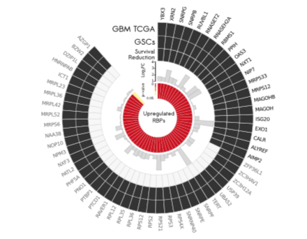

From https://genomebiology.biomedcentral.com/articles/10.1186/s13059-016-0990-4

Fig. 2 Candidates’ selection and characterization. a. Circos plot shows **58 upregulated RNA-binding proteins (RBPs)** in glioblastoma (GBM) samples from The Cancer Genome Atlas (TCGA) and glioma stem cell (GSC) lines. **Fold-changes and corrected p-values** were extracted from the RNA-Seq analysis (GBM TCGA). Twenty-one RBPs were also associated with survival reduction and were further investigated.

## 3 应用场景 Application scenarios

圆圈图上用热图、柱形图、热图展示多组数据、pvalue和log2FC，可灵活换成其他特征值。

Use heatmaps, bar charts, and heatmaps on the circle chart to display multiple sets of data, p-values, and log2FC, which can be flexibly replaced with other feature values.

## 4 环境设置 Environment settings

```r
source("install_dependencies.R")
```

```
## Starting R package installation...
## ===========================================
##
## Installing CRAN packages...
## Package already installed: dplyr
## Package already installed: ggplot2
## Package already installed: magrittr
## Package already installed: readxl
## Package already installed: tibble
##
## ===========================================
## Package installation completed!
## You can now run your R scripts in this directory.
```

```r
# 加载数据处理和可视化所需的包
# Load packages required for data processing and visualization
library(readxl)      # 用于读取Excel文件 / For reading Excel files
library(magrittr)    # 提供管道操作符 %>% / Provides pipe operator %>%
library(dplyr)       # 数据处理工具集 / Data manipulation toolkit
library(tibble)      # 增强型数据框 / Enhanced data frames
library(ggplot2)     # 用于数据可视化 / For data visualization

# 设置环境选项
# Set environment options
Sys.setenv(LANGUAGE = "en")  # 设置英文错误信息，便于查找解决方案 / Set English error messages for easier troubleshooting
options(stringsAsFactors = FALSE)  # 禁止自动将字符串转换为因子类型，避免数据类型意外转换 / Prevent automatic conversion of strings to factors
```

## 5 输入数据的整理 Organizing input data

如果你的数据已经整理成easy_input.csv的格式，就可以跳过这步，直接进入“输入文件”。

从文献中看，需要读取`TableS2.TCGA_GBM_DiffExpRBPs`和`TableS3.GSCs_DiffExpRBPs`两个sheet。

另外，图中基因是按照Survival Reduction排列的，根据图反推survival Reduction，保存在survival.csv文件里。

If your data has already been organized into easy_input.csv format, you can skip this step and directly enter “Input File”.

According to the literature, it is necessary to read two sheets, ‘TableS2. TCGA-GBM-DiffExpRBPs’ and’ TableS3. GSCs_DiffExpRBPs’.

In addition, the genes in the figure are arranged according to the Survival Reduction. Based on the figure, the Survival Reduction is deduced and saved in the Survival.csv file.

```r
## 读取第2个工作表
# Read the second worksheet
# 从Excel文件中读取指定范围数据，设置表头并限制数据探测行数
sheet1 <- read_excel(path = "13059_2016_990_MOESM1_ESM.xls", sheet = 2, range = cell_cols("B:D"), col_names = TRUE, guess_max = 5)

## 读取第3个工作表
# Read the third worksheet
# 从Excel文件中读取指定范围数据，移除第二列后存储
sheet2 <- read_excel(path = "13059_2016_990_MOESM1_ESM.xls", sheet = 3, range = cell_cols("B:E"), col_names = TRUE, guess_max = 5) %>% .[,-2]

# 首先重命名变量，原来的变量名太长了
# Rename columns for clarity
colnames(sheet1) <- c("Gene", "log2FC", "P_value")  # 重命名工作表1的列名 / Rename columns of sheet1
colnames(sheet2) <- c("Gene", "log2FC", "P_value")  # 重命名工作表2的列名 / Rename columns of sheet2

# Circos plot shows 58 upregulated RNA-binding proteins (RBPs) in glioblastoma (GBM) samples from The Cancer Genome Atlas (TCGA) and glioma stem cell (GSC) lines.
# 根据文献中的要求，首先筛选log2FC大于0的基因
# Filter genes with log2 fold change >= 0 as required by the literature
sheet1 %<>% filter(log2FC >= 0)  # 筛选工作表1中log2FC非负的基因 / Filter upregulated genes in sheet1
sheet2 %<>% filter(log2FC >= 0) %>% select(Gene)  # 筛选工作表2中log2FC非负的基因并仅保留基因列 / Filter and select genes in sheet2

# Fold-changes and corrected p-values were extracted from the RNA-Seq analysis (GBM TCGA)
# 根据Gene取交集，保留GBM的Fold-changes和corrected p-values
# Merge datasets by gene intersection, retaining GBM fold changes and p-values
sheet_bind <- inner_join(sheet1, sheet2, by = "Gene") %>%
  distinct(Gene, .keep_all = TRUE)  #去重 / Remove duplicate entries
sheet_bind$GBM <- rep(1, nrow(sheet_bind))  # 添加GBM标识列 / Add GBM indicator column
sheet_bind$GSC <- rep(1, nrow(sheet_bind))  # 添加GSC标识列 / Add GSC indicator column

# 跟Survival Reduction合并
# Merge with survival reduction data
surInfo <- read.csv("survival.csv")  # 读取生存分析数据 / Read survival data
head(surInfo)  # 查看数据结构 / View data structure
```

```
##     Gene survival
## 1  AIMP2        1
## 2 ALYREF        1
## 3  AZGP1        0
## 4   BZW2        0
## 5   CALR        1
## 6 DZIP1L        0
```

```r
#先按基因名降序排列基因名
# Sort genes by name in descending order
surInfo <- arrange(surInfo, desc(Gene))
#合并后按survival降序排列
# Merge datasets and sort by survival in descending order
data_bind <- left_join(surInfo, sheet_bind, by = "Gene") %>% arrange(desc(survival))
head(data_bind)  # 查看合并结果 / View merged data
```

```
##      Gene survival   log2FC      P_value GBM GSC
## 1    YBX3        1 1.488045 1.283042e-09   1   1
## 2    XRN2        1 1.436980 1.292371e-33   1   1
## 3   SNRPG        1 2.272819 3.507441e-22   1   1
## 4   SNRPB        1 1.622813 4.456042e-14   1   1
## 5  RUVBL1        1 1.600344 2.835265e-46   1   1
## 6 RNASET2        1 1.143558 2.908991e-06   1   1
```

```r
# 导出分析结果为CSV文件
# Export analysis results to CSV
write.csv(data_bind, "easy_input.csv", quote = F, row.names = F)
```

## 6 输入文件 Input file

至少包含基因、log2FC、P_value，给出一列或多列的01用于画最外面的圈。

此处把GBM、GSC、survival画到最外面的三个圈上，有就是1（最后显示为黑色），无就是0（最后显示为浅灰色）。

用柱形图展示log2FC，用热图展示P value。

At least including genes log2FC、P_value， Give one or more columns of 01 to draw the outermost circle.

Draw GBM, GSC, and Survival on the outermost three circles here, where ‘1’ represents’ 1 ‘(displayed in black) and’ 0 ‘represents’ 0’ (displayed in light gray).

Display log2FC using a bar chart and P value using a heatmap.

```r
# 读取之前导出的CSV文件，指定各列数据类型
# Read the previously exported CSV file, specifying data types for each column
data_bind <- read.csv("easy_input.csv",
                      colClasses=c('character',  # Gene列作为字符型 / Gene column as character
                                  'numeric',   # survival列作为数值型 / survival column as numeric
                                  'numeric',   # GBM_log2FC列作为数值型 / GBM_log2FC column as numeric
                                  'numeric',   # GBM_P_value列作为数值型 / GBM_P_value column as numeric
                                  'numeric',   # GSC列作为数值型 / GSC column as numeric
                                  'numeric'))  # GBM列作为数值型 / GBM column as numeric

# 查看数据的基本结构和前几行
# View the basic structure and first few rows of the data
head(data_bind)
```

```
##      Gene survival   log2FC      P_value GBM GSC
## 1    YBX3        1 1.488045 1.283042e-09   1   1
## 2    XRN2        1 1.436980 1.292371e-33   1   1
## 3   SNRPG        1 2.272819 3.507441e-22   1   1
## 4   SNRPB        1 1.622813 4.456042e-14   1   1
## 5  RUVBL1        1 1.600344 2.835265e-46   1   1
## 6 RNASET2        1 1.143558 2.908991e-06   1   1
```

## 7 开始画图 Start drawing

### 7.1 首先画外面的3个环 First, draw the three outer rings

环形文字的写法：https://www.r-graph-gallery.com/296-add-labels-to-circular-barplot/

The writing style of circular text:< https://www.r-graph-gallery.com/296-add-labels-to-circular-barplot/ >

```r
# 三个环的坐标设置：稍高于log2FC的最大值，确保数据点不重叠
# Coordinates for the three outer rings: Slightly higher than the maximum log2FC value to avoid overlap
h <- max(data_bind$log2FC) + 0.2

# 创建环形图坐标数据框
# Create coordinate dataframe for circular plot
tile_coord <- data.frame(
  Gene = data_bind$Gene,
  x = 1:nrow(data_bind),          # x是中间x坐标 / Middle x-coordinate for each gene
  y1 = h, y2 = h + 2, y3 = h + 4, # 最外围三个圈的y坐标 / y-coordinates for the three outer rings
  stringsAsFactors = FALSE
)

# 设置基因名称显示参数
# Set parameters for gene name display
Angle_space <- 8    # 设置角度空隙大小 / Angular spacing between genes
Angle_just <- 90    # 角度偏移量 / Angular offset for text alignment

# 计算每个基因的角度位置
# Calculate angular positions for each gene
unit_angle <- 360 / (nrow(tile_coord) + Angle_space + 0.5)  # 单位角度 / Angular unit per gene
text_angle <- Angle_just - cumsum(rep(unit_angle, nrow(tile_coord)))  # 文本角度 / Text rotation angle

# 根据角度调整文本对齐方式，避免文字倒置
# Adjust text alignment to prevent upside-down labels
tile_coord$hjust <- ifelse(text_angle < -90, 1, 0)  # 水平对齐方式 / Horizontal alignment
tile_coord$text_angle <- ifelse(text_angle < -90, text_angle + 180, text_angle)  # 修正极端角度 / Correct extreme angles

# 合并坐标数据与原始数据
# Merge coordinate data with original dataset
data_result <- left_join(data_bind, tile_coord, by = "Gene")
head(data_result)
```

```
##      Gene survival   log2FC      P_value GBM GSC x       y1       y2       y3
## 1    YBX3        1 1.488045 1.283042e-09   1   1 1 4.118675 6.118675 8.118675
## 2    XRN2        1 1.436980 1.292371e-33   1   1 2 4.118675 6.118675 8.118675
## 3   SNRPG        1 2.272819 3.507441e-22   1   1 3 4.118675 6.118675 8.118675
## 4   SNRPB        1 1.622813 4.456042e-14   1   1 4 4.118675 6.118675 8.118675
## 5  RUVBL1        1 1.600344 2.835265e-46   1   1 5 4.118675 6.118675 8.118675
## 6 RNASET2        1 1.143558 2.908991e-06   1   1 6 4.118675 6.118675 8.118675
##   hjust text_angle
## 1     0   84.58647
## 2     0   79.17293
## 3     0   73.75940
## 4     0   68.34586
## 5     0   62.93233
## 6     0   57.51880
```

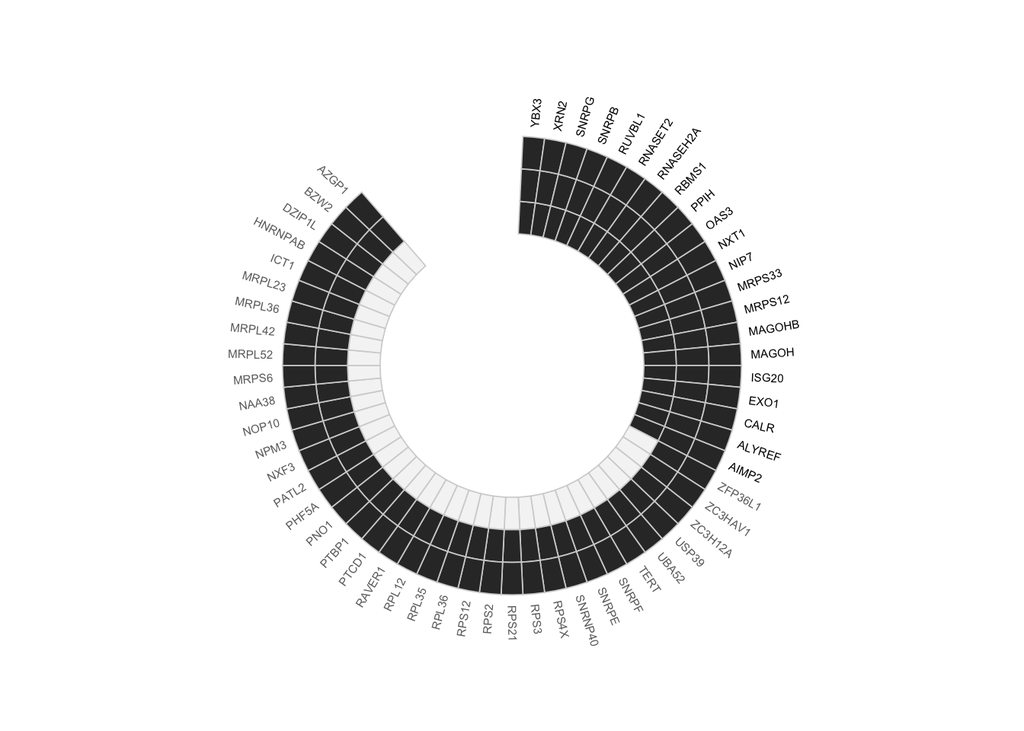

```r
# 使用ggplot2创建环形图
# Create circular plot using ggplot2
p1 <- ggplot(data_result) +
  # 第一圈：生存状态(Survival)
  # First ring: Survival status
  geom_tile(data = filter(data_result, survival == 1),
            aes(x = x, y = y1, width = 1, height = 2),
            fill = "grey20", color = "lightgrey", size = .3) +  # 生存组 / Survival group
  geom_tile(data = filter(data_result, survival == 0),
            aes(x = x, y = y1, width = 1, height = 2),
            fill = "grey96", color = "lightgrey", size = .3) +  # 非生存组 / Non-survival group

  # 第二圈：GSC状态
  # Second ring: GSC status
  geom_tile(data = filter(data_result, GSC == 1),
            aes(x = x, y = y2, width = 1, height = 2),
            fill = "grey20", color = "lightgrey", size = .3) +  # GSC阳性 / GSC positive
  # 如果有0值，取消下面三行注释
  # Uncomment below if there are GSC negative values
  # geom_tile(data = filter(data_result, GSC == 0),
  #          aes(x = x, y = y2, width = 1, height = 2),
  #          fill = "grey96", color = "lightgrey", size = .3) +

  # 第三圈：GBM状态
  # Third ring: GBM status
  geom_tile(data = filter(data_result, GBM == 1),
            aes(x = x, y = y3, width = 1, height = 2),
            fill = "grey20", color = "lightgrey", size = .3) +  # GBM阳性 / GBM positive
  # 如果有0值，取消下面三行注释
  # Uncomment below if there are GBM negative values
  # geom_tile(data = filter(data_result, GBM == 0),
  #          aes(x = x, y = y3, width = 1, height = 2),
  #          fill = "grey96", color = "lightgrey", size = .3) +
  # 如果需要更多圈，可以继续添加

  # 添加基因名称标签：survival为1的基因名为黑色，否则为浅灰色
  # Add gene names: Black for survival=1, grey for survival=0
  geom_text(data = filter(data_result, survival == 1),
            aes(x = x, y = y3 + 1.6, label = Gene,
                angle = text_angle, hjust = hjust), color = "black", size = 2) +
  geom_text(data = filter(data_result, survival == 0),
            aes(x = x, y = y3 + 1.6, label = Gene,
                angle = text_angle, hjust = hjust), color = "grey43", size = 2) +

  # 转换为极坐标系统
  # Convert to polar coordinates
  coord_polar(theta = "x", start = 0, direction = 1) +
  ylim(-5,13) +  # 设置y轴范围 / Set y-axis limits
  xlim(0, nrow(data_bind) + Angle_space) +  # 设置x轴范围 / Set x-axis limits
  theme_void()  # 使用空白主题 / Apply minimal theme
p1  # 显示图形 / Display plot
```

### 7.2 画`log2FC` Draw ‘log2FC’`

log2FC的y坐标从1开始，因此画图时要“y = log2FC - 1”

The y-coordinate of log2FC starts from 1, so when drawing, it should be “y=log2FC -1”

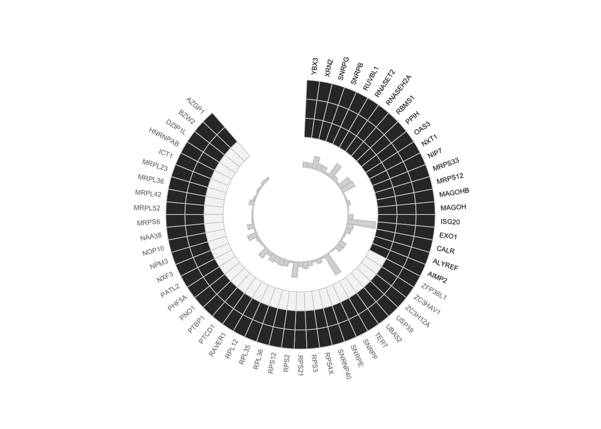

```r
# 在原有图形(p1)基础上叠加柱状图层，展示log2FC数据
# Add bar chart layer to the original plot (p1) to show log2FC values
p2 <- p1 +
  geom_col(
    aes(x = x, y = log2FC - 1),
    fill = "grey85",
    color = "grey80"
  )

p2
```

### 7.3 添加log2FC的坐标轴及刻度文字 Add coordinate axis and scale text for log2FC

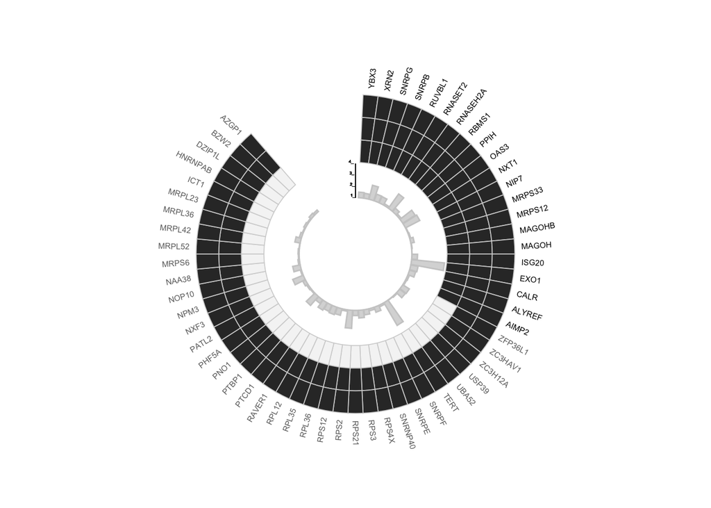

```r
# 在原有图形(p2)基础上添加坐标轴标记和参考线
# Add axis markers and reference lines to the existing plot (p2)
p3 <- p2 +
  # 添加垂直参考线（从原点到y=3）
  # Add vertical reference line from origin to y=3
  geom_segment(
    x = 0, y = 0, xend = 0, yend = 3,
    color = "black", size = .3
  ) +

  # 添加y轴刻度标签（1-4）
  # Add y-axis tick labels (1-4)
  geom_text(x = -.5, y = 0, label = "1_", vjust = -.3, size = 1, color = "black") +
  geom_text(x = -.5, y = 1, label = "2_", vjust = -.3, size = 1, color = "black") +
  geom_text(x = -.5, y = 2, label = "3_", vjust = -.3, size = 1, color = "black") +
  geom_text(x = -.5, y = 3, label = "4_", vjust = -.3, size = 1, color = "black")

p3
```

### 7.4 画`P_value`热图 Draw a ‘P_value’ heatmap

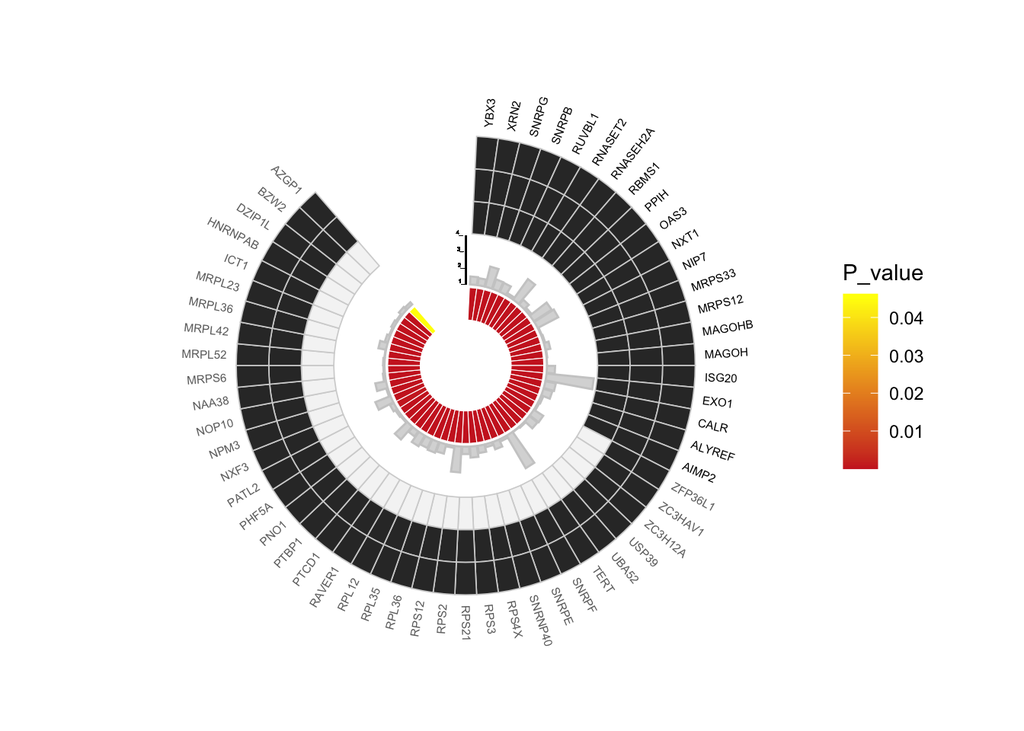

```r
# 在原有图形(p3)基础上添加P值热图层
# Add P-value heatmap layer to the existing plot (p3)
p4 <- p3 +
  # 添加P值热图：位于y=-1.2位置，每个基因对应一个矩形
  # Add P-value heatmap: Positioned at y=-1.2, each gene is represented by a rectangle
  geom_tile(
    aes(x = x, y = -1.2, width = 1, height = 2, fill = P_value),
    color = "white"
  ) +

  # 设置填充颜色渐变：P值越小颜色越深（firebrick3），越大颜色越浅（yellow）
  # Set color gradient: Smaller P-values are darker (firebrick3), larger values are lighter (yellow)
  scale_fill_gradient(
    low = "firebrick3",
    high = "yellow"
  )

p4
```

### 7.5 插入文本 Insert Text

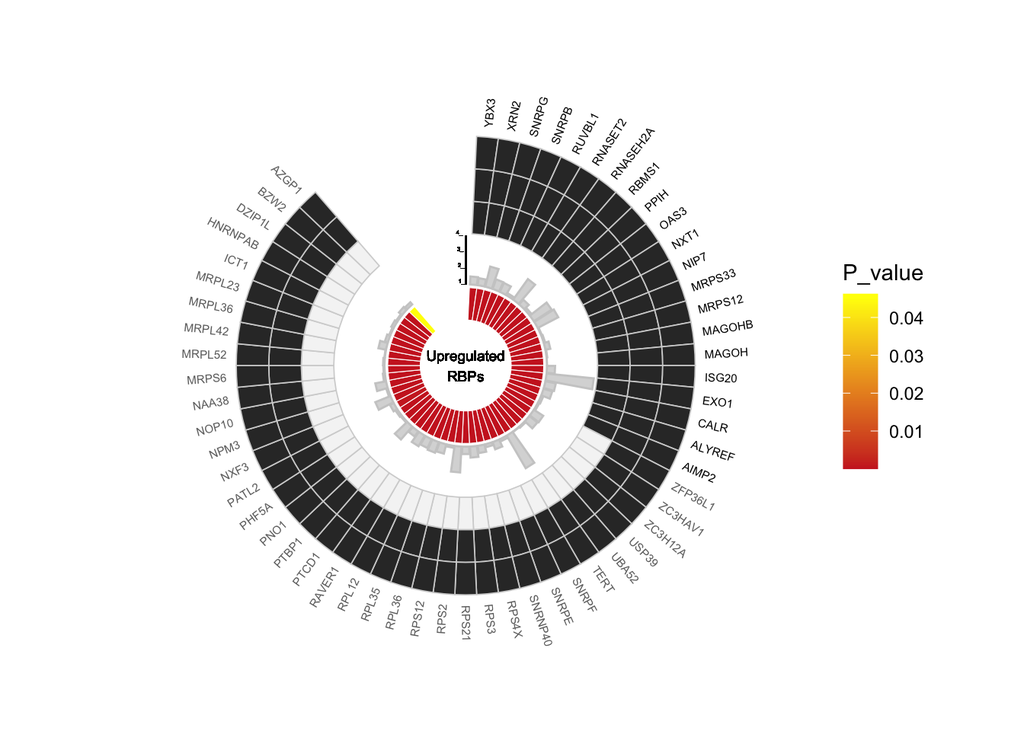

```r
# 在原有图形(p4)基础上添加各数据层的文本标签
# Add text labels for each data layer to the existing plot (p4)

# First, ensure 'h' is properly defined (this should be defined earlier in your code)
# If not, you'll need to calculate or define an appropriate value for h
# h <- [appropriate value based on your data]

p5 <- p4 +
  # 添加GBM TCGA层标签
  # Label for GBM TCGA layer
  geom_text(aes(x = -2.1, y = h + 4.5, label = "GBM TCGA"),
            size = 3, color = "black", inherit.aes = FALSE) +

  # 添加GSCs层标签
  # Label for GSCs layer
  geom_text(aes(x = -1.1, y = h + 2.5, label = "GSCs"),
            size = 3, color = "black", inherit.aes = FALSE) +

  # 添加Survival Reduction层标签（支持换行）
  # Label for Survival Reduction layer (with line break)
  geom_text(aes(x = -1.8, y = h + 0.5, label = "Survival\nReduction"),
            size = 2.5, color = "black", inherit.aes = FALSE) +

  # 添加Log2FC坐标轴标签（旋转90度）
  # Label for Log2FC axis (rotated 90 degrees)
  geom_text(aes(x = -2.1, y = h - 2.4, label = "Log[2]~FC"),
            angle = 90, size = 2.2, color = "black", parse = TRUE, inherit.aes = FALSE) +

  # 添加p-value热图层标签（旋转90度）
  # Label for p-value heatmap (rotated 90 degrees)
  geom_text(aes(x = -3.3, y = h - 5, label = "p-value"),
            angle = 90, size = 1.5, color = "black", inherit.aes = FALSE) +

  # 添加中心标题（支持换行）
  # Add center title (with line break)
  geom_text(aes(x = 0, y = -5, label = "Upregulated\nRBPs"),
            size = 2.5, color = "black", inherit.aes = FALSE)

p5
```

### 7.6 画P value的图例 Draw a legend for P value

将图例调整到panel内部，并且调节文本的相对大小和相对位置。

Adjust the legend inside the panel and adjust the relative size and position of the text.

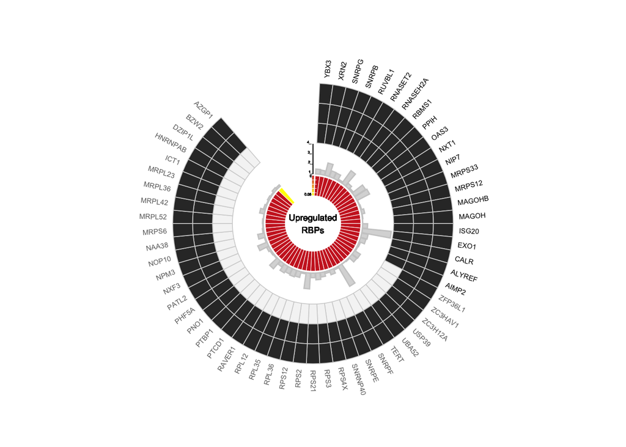

```r
# 在原有图形(p5)基础上添加p值参考刻度和图例
# Add p-value reference scale and legend to the existing plot (p5)
p6 <- p5 +
  # 添加p值=0的参考标记
  # Add reference mark for p-value=0
  geom_text(x = -.5, y = -0.2, label = 0, size = 1, color = "black") +

  # 添加p值=0.05的参考标记（对应热图中黄色区域）
  # Add reference mark for p-value=0.05 (corresponding to yellow area in heatmap)
  geom_text(x = -1.8, y = -2, label = 0.05, size = 1, color = "black") +

  # 自定义颜色渐变图例
  # Customize color gradient legend
  guides(fill = guide_colorbar(
    title = "",
    reverse = TRUE,
    label = FALSE,
    barwidth = 0.1,
    barheight = 1.1
  )) +

  # 设置图例位置和样式
  # Set legend position and style
  theme(
    legend.position = c(0.5, 0.585),
    legend.title = element_blank()
  )

p6  # 显示最终图形
```

```r
# 保存图形为PDF文件
# Save the plot as a PDF file
ggsave("ggplotCircos.pdf")
```

## 8 后期加工 Post processing

前面的代码通过x和y的值一点一点调整好文字和图例的位置。

更容易的做法是：用矢量图编辑软件打开pdf文件，用鼠标调整。

The previous code adjusted the position of the text and legend bit by bit based on the values of x and y.

An easier approach is to open the PDF file with vector graphics editing software and adjust it with the mouse.